# Análisis Datos ELSOC

# 1 Librerías

```r
pacman::p_load(dplyr, #Manipulacion de datos
              stargazer, #Tablas
              sjmisc, # Tablas
              summarytools, # Tablas
              kableExtra, #Tablas
              sjPlot, #Tablas y gráficos
              corrplot, # Correlaciones
              sessioninfo) # Información de la sesión de trabajo
```

# 2 Cargar base de datos preparada

```r
load("../input/data/proc/ELSOC_ess_merit2016.RData") #Cargar base de datos
```

- Exploración inicial general de la base de datos

```r
names(proc_elsoc) # Muestra los nombres de las variables de la base de datos
```

```
## [1] "mesfuerzo" "mtalento"  "ess"       "edcine"    "sexo"      "edad"
## [7] "pmerit"
```

```r
dim(proc_elsoc) # Dimensiones
```

```
## [1] 2927    7
```

En el caso de esta base, 2927 casos y 7 variables

Recordando el contenido de cada variable:

- [`merit`] = Indice promedio de percepción de meritocracia.
- [`ess`] = Estatus Social Subjetivo: Donde se ubicaria ud. en la sociedad chilena" (0 = el nivel mas bajo; 10 = el nivel mas alto)
- [`edcine`] = Nivel educacional(1 = Primaria incompleta menos, 2 = Primaria y secundaria baja, 3 = Secundaria alta, 4 = Terciaria ciclo corto, 5 = Terciaria y Postgrado)
- [`sexo`] = Sexo (O = Hombre; 1 = Mujer)
- [`edad`] = ¿Cuáles su edad? (años cumplidos)

# 3 Descripción de variables

Los resultados referidos a descripción de variables se presentan en dos momentos del reporte de investigación:

- en la sección de *metodología*, cuando se presentan las variables del estudio en una **tabla descriptiva** de variables.
- en la sección de *análisis*, que en general comienza con una exploración de **asociaciones entre variables**, también conocido como análisis descriptivo.

## 3.1 Tabla descriptiva de variables para sección metodológica

A continuación se presentan dos opciones de generar esta tabla descriptiva de variables con distintas librerías de R.

**a. Tabla descriptiva con `stargazer`**

```r
stargazer(proc_elsoc,type = "text")
```

```
##
## ==============================================================
## Statistic   N    Mean  St. Dev.  Min  Pctl(25) Pctl(75)  Max
## --------------------------------------------------------------
## mesfuerzo 2,909 2.573   1.047   1.000  2.000    3.000   5.000
## mtalento  2,907 2.739   1.060   1.000  2.000    4.000   5.000
## ess       2,915 4.330   1.567   0.000  3.000    5.000   10.000
## edcine    2,925 3.184   1.207   1.000  3.000    4.000   5.000
## sexo      2,927 0.603   0.489     0      0        1       1
## edad      2,927 46.091  15.287   18      33       58      88
## pmerit    2,898 2.654   0.969   1.000  2.000    3.500   5.000
## --------------------------------------------------------------
```

**b. Tablas descriptivas con `descr`, librería sjmisc**

```r
sjmisc::descr(proc_elsoc)
```

```
##
## ## Basic descriptive statistics
##
##        var    type                    label    n NA.prc  mean    sd   se   md
##  mesfuerzo numeric     Recompensa: esfuerzo 2909   0.61  2.57  1.05 0.02  2.0
##   mtalento numeric      Recompensa: talento 2907   0.68  2.74  1.06 0.02  3.0
##        ess numeric Estatus Social Subjetivo 2915   0.41  4.33  1.57 0.03  5.0
##     edcine numeric                Educación 2925   0.07  3.18  1.21 0.02  3.0
##       sexo numeric                     Sexo 2927   0.00  0.60  0.49 0.01  1.0
##       edad numeric                     Edad 2927   0.00 46.09 15.29 0.28 46.0
##     pmerit numeric    Meritocracia promedio 2898   0.99  2.65  0.97 0.02  2.5
##  trimmed      range  iqr  skew
##     2.56    4 (1-5)  1.0  0.42
##     2.76    4 (1-5)  2.0  0.18
##     4.36  10 (0-10)  2.0 -0.01
##     3.23    4 (1-5)  1.0 -0.15
##     0.63    1 (0-1)  1.0 -0.42
##    45.90 70 (18-88) 25.0  0.07
##     2.66    4 (1-5)  1.5  0.26
```

Seleccionamos algunas columnas específicas con información más relevante con la opción `show`. Además, agregamos la función `kable` para obtener una tabla que luego sea fácilmente publicable en distintos formatos:

```r
sjmisc::descr(proc_elsoc,
      show = c("label","range", "mean", "sd", "NA.prc", "n"))%>%
      kable(.,"markdown")
```

|  | var | label | n | NA.prc | mean | sd | range |
| --- | --- | --- | --- | --- | --- | --- | --- |
| 4 | mesfuerzo | Recompensa: esfuerzo | 2909 | 0.6149641 | 2.5727054 | 1.0466874 | 4 (1-5) |
| 5 | mtalento | Recompensa: talento | 2907 | 0.6832935 | 2.7389061 | 1.0596182 | 4 (1-5) |
| 3 | ess | Estatus Social Subjetivo | 2915 | 0.4099761 | 4.3300172 | 1.5666965 | 10 (0-10) |
| 2 | edcine | Educación | 2925 | 0.0683293 | 3.1839316 | 1.2066058 | 4 (1-5) |
| 7 | sexo | Sexo | 2927 | 0.0000000 | 0.6026648 | 0.4894300 | 1 (0-1) |
| 1 | edad | Edad | 2927 | 0.0000000 | 46.0908780 | 15.2867983 | 70 (18-88) |
| 6 | pmerit | Meritocracia promedio | 2898 | 0.9907755 | 2.6538992 | 0.9694792 | 4 (1-5) |

**c. Tabla descriptiva con `summarytools::dfSummary`**

Esta tercera opción nos ofrece una tabla aún más detallada, con gráficos para cada variable, las frecuencias para cada valor, y las etiquetas de las variables, por lo que es muy recomendable.

Se específica de la siguiente manera:

```r
dfSummary(proc_elsoc, plain.ascii = FALSE)
```

```
## ### Data Frame Summary
## #### proc_elsoc
## **Dimensions:** 2927 x 7
## **Duplicates:** 396
##
## ----------------------------------------------------------------------------------------------------------------------------------------
## No   Variable     Label                      Stats / Values             Freqs (% of Valid)     Graph                Valid      Missing
## ---- ------------ -------------------------- -------------------------- ---------------------- -------------------- ---------- ---------
## 1    mesfuerzo\   Recompensa: esfuerzo       Mean (sd) : 2.6 (1)\       1 :  357 (12.3%)\      II \                 2909\      18\
##      [numeric]                               min < med < max:\          2 : 1331 (45.8%)\      IIIIIIIII \          (99.39%)   (0.61%)
##                                              1 < 2 < 5\                 3 :  497 (17.1%)\      III \
##                                              IQR (CV) : 1 (0.4)         4 :  646 (22.2%)\      IIII \
##                                                                         5 :   78 ( 2.7%)
##
## 2    mtalento\    Recompensa: talento        Mean (sd) : 2.7 (1.1)\     1 :  288 ( 9.9%)\      I \                  2907\      20\
##      [numeric]                               min < med < max:\          2 : 1163 (40.0%)\      IIIIIIII \           (99.32%)   (0.68%)
##                                              1 < 3 < 5\                 3 :  559 (19.2%)\      III \
##                                              IQR (CV) : 2 (0.4)         4 :  814 (28.0%)\      IIIII \
##                                                                         5 :   83 ( 2.9%)
##
## 3    ess\         Estatus Social Subjetivo   Mean (sd) : 4.3 (1.6)\     11 distinct values     \                    2915\      12\
##      [numeric]                               min < med < max:\                                 \ \ \ \ \ \ \ \ :\   (99.59%)   (0.41%)
##                                              0 < 5 < 10\                                       \ \ \ \ \ \ . :\
##                                              IQR (CV) : 2 (0.4)                                \ \ \ \ . : :\
##                                                                                                \ \ \ \ : : : .\
##                                                                                                . : : : : : .
##
## 4    edcine\      Educación                  Mean (sd) : 3.2 (1.2)\     1 :  359 (12.3%)\      II \                 2925\      2\
##      [numeric]                               min < med < max:\          2 :  297 (10.2%)\      II \                 (99.93%)   (0.07%)
##                                              1 < 3 < 5\                 3 : 1251 (42.8%)\      IIIIIIII \
##                                              IQR (CV) : 1 (0.4)         4 :  483 (16.5%)\      III \
##                                                                         5 :  535 (18.3%)       III
##
## 5    sexo\        Sexo                       Min  : 0\                  0 : 1163 (39.7%)\      IIIIIII \            2927\      0\
##      [numeric]                               Mean : 0.6\                1 : 1764 (60.3%)       IIIIIIIIIIII         (100%)     (0%)
##                                              Max  : 1
##
## 6    edad\        Edad                       Mean (sd) : 46.1 (15.3)\   63 distinct values     \                    2927\      0\
##      [numeric]                               min < med < max:\                                 \ \ . . . : :\       (100%)     (0%)
##                                              18 < 46 < 88\                                     . : : : : : .\
##                                              IQR (CV) : 25 (0.3)                               : : : : : : : :\
##                                                                                                : : : : : : : :\
##                                                                                                : : : : : : : : .
##
## 7    pmerit\      Meritocracia promedio      Mean (sd) : 2.7 (1)\       1.00 :  243 ( 8.4%)\   I \                  2898\      29\
##      [numeric]                               min < med < max:\          1.50 :   79 ( 2.7%)\   \                    (99.01%)   (0.99%)
##                                              1 < 2.5 < 5\               2.00 : 1041 (35.9%)\   IIIIIII \
##                                              IQR (CV) : 1.5 (0.4)       2.50 :  222 ( 7.7%)\   I \
##                                                                         3.00 :  536 (18.5%)\   III \
##                                                                         3.50 :  169 ( 5.8%)\   I \
##                                                                         4.00 :  528 (18.2%)\   III \
##                                                                         4.50 :   38 ( 1.3%)\   \
##                                                                         5.00 :   42 ( 1.5%)
## ----------------------------------------------------------------------------------------------------------------------------------------
```

Es muy ancha para visualizar bien en la consola de R, pero en su versión más definitiva de publicación se verá así:

| **No** | **Variable** | **Label** | **Stats / Values** | **Freqs (% of Valid)** | **Graph** | **Valid** | **Missing** |
| --- | --- | --- | --- | --- | --- | --- | --- |
| 1 | mesfuerzo [numeric] | Recompensa: esfuerzo | Mean (sd) : 2.6 (1) min < med < max: 1 < 2 < 5 IQR (CV) : 1 (0.4) | 1 : 357 ( 12.3% ) 2 : 1331 ( 45.8% ) 3 : 497 ( 17.1% ) 4 : 646 ( 22.2% ) 5 : 78 ( 2.7% ) |  | 2909 (99.39%) | 18 (0.61%) |
| 2 | mtalento [numeric] | Recompensa: talento | Mean (sd) : 2.7 (1.1) min < med < max: 1 < 3 < 5 IQR (CV) : 2 (0.4) | 1 : 288 ( 9.9% ) 2 : 1163 ( 40.0% ) 3 : 559 ( 19.2% ) 4 : 814 ( 28.0% ) 5 : 83 ( 2.9% ) |  | 2907 (99.32%) | 20 (0.68%) |
| 3 | ess [numeric] | Estatus Social Subjetivo | Mean (sd) : 4.3 (1.6) min < med < max: 0 < 5 < 10 IQR (CV) : 2 (0.4) | 11 distinct values |  | 2915 (99.59%) | 12 (0.41%) |
| 4 | edcine [numeric] | Educación | Mean (sd) : 3.2 (1.2) min < med < max: 1 < 3 < 5 IQR (CV) : 1 (0.4) | 1 : 359 ( 12.3% ) 2 : 297 ( 10.2% ) 3 : 1251 ( 42.8% ) 4 : 483 ( 16.5% ) 5 : 535 ( 18.3% ) |  | 2925 (99.93%) | 2 (0.07%) |
| 5 | sexo [numeric] | Sexo | Min : 0 Mean : 0.6 Max : 1 | 0 : 1163 ( 39.7% ) 1 : 1764 ( 60.3% ) |  | 2927 (100%) | 0 (0%) |
| 6 | edad [numeric] | Edad | Mean (sd) : 46.1 (15.3) min < med < max: 18 < 46 < 88 IQR (CV) : 25 (0.3) | 63 distinct values |  | 2927 (100%) | 0 (0%) |
| 7 | pmerit [numeric] | Meritocracia promedio | Mean (sd) : 2.7 (1) min < med < max: 1 < 2.5 < 5 IQR (CV) : 1.5 (0.4) | 1.00 : 243 ( 8.4% ) 1.50 : 79 ( 2.7% ) 2.00 : 1041 ( 35.9% ) 2.50 : 222 ( 7.7% ) 3.00 : 536 ( 18.5% ) 3.50 : 169 ( 5.8% ) 4.00 : 528 ( 18.2% ) 4.50 : 38 ( 1.3% ) 5.00 : 42 ( 1.5% ) |  | 2898 (99.01%) | 29 (0.99%) |

Generated by summarytools 0.9.6 ([R](https://www.r-project.org/) version 4.0.0)  
2020-06-23

**Nota sobre casos perdidos (NAs)**

Se recomienda el siguiente procedimiento:

- respaldar la base de datos original en el espacio de trabajo (por si queremos en adelante realizar algún análisis referido a casos perdidos), la dejaremos con el nombre proc_elsoc_original.
- contamos el número de casos con el comando `dim`
- contamos el número de casos perdidos con `sum(is.na(proc_elsoc))`
- borramos los casos perdidos con `proc_elsoc <-na.omit(proc_elsoc)`
- contamos nuevamente con `dim` para asegurarnos que se borraron
- y por temas de funcionamiento de R, al realizar la operación de sacar casos perdidos, se borra toda la información de las etiquetas (labels), así que las recuperamos de la base original con el comando `copy_labels`, de la librería `sjlabelled`.

```r
proc_elsoc_original <-proc_elsoc
dim(proc_elsoc)
```

```
## [1] 2927    7
```

```r
sum(is.na(proc_elsoc))
```

```
## [1] 81
```

```r
proc_elsoc <-na.omit(proc_elsoc)
dim(proc_elsoc)
```

```
## [1] 2887    7
```

```r
proc_elsoc <-sjlabelled::copy_labels(proc_elsoc,proc_elsoc_original)
```

## 3.2 Exploración de asociación entre variables

### 3.2.1 Tablas de contingencia para variables categóricas

```r
sjt.xtab(proc_elsoc$edcine, proc_elsoc$sexo,
        show.col.prc=TRUE,
        show.summary=FALSE
)
```

| Educación | Sexo |  | Total |  |
| --- | --- | --- | --- | --- |
|  | Hombre | Mujer |  |  |
| Primaria incompleta menos | 102 8.9 % | 247 14.2 % |  | 349 12.1 % |
| Primaria y secundaria baja | 105 9.1 % | 186 10.7 % | 291 10.1 % |  |
| Secundaria alta | 511 44.5 % | 727 41.8 % | 1238 42.9 % |  |
| Terciaria ciclo corto | 186 16.2 % | 292 16.8 % | 478 16.6 % |  |
| Terciaria y Postgrado | 245 21.3 % | 286 16.5 % | 531 18.4 % |  |
| Total | 1149 100 % | 1738 100 % | 2887 100 % |  |

### 3.2.2 Tablas de promedio de variable continua por una categóricas

```r
tapply(proc_elsoc$pmerit, proc_elsoc$edcine, mean)
```

```
##        1        2        3        4        5
## 2.968481 2.697595 2.662763 2.479079 2.559322
```

```r
proc_elsoc %>% # se especifica la base de datos
  select(pmerit,edcine) %>% # se seleccionan las variables
  dplyr::group_by(Educación=sjlabelled::as_label(edcine)) %>% # se agrupan por la variable categórica y se usan sus etiquetas con as_label
  dplyr::summarise(Obs.=n(),Promedio=mean(pmerit),SD=sd(pmerit)) %>% # se agregan las operaciones a presentar en la tabla
  kable(, format = "markdown") # se genera la tabla
```

| Educación | Obs. | Promedio | SD |
| --- | --- | --- | --- |
| Primaria incompleta menos | 349 | 2.968481 | 0.9828315 |
| Primaria y secundaria baja | 291 | 2.697595 | 1.0041093 |
| Secundaria alta | 1238 | 2.662762 | 0.9685655 |
| Terciaria ciclo corto | 478 | 2.479080 | 0.9431323 |
| Terciaria y Postgrado | 531 | 2.559322 | 0.9223446 |

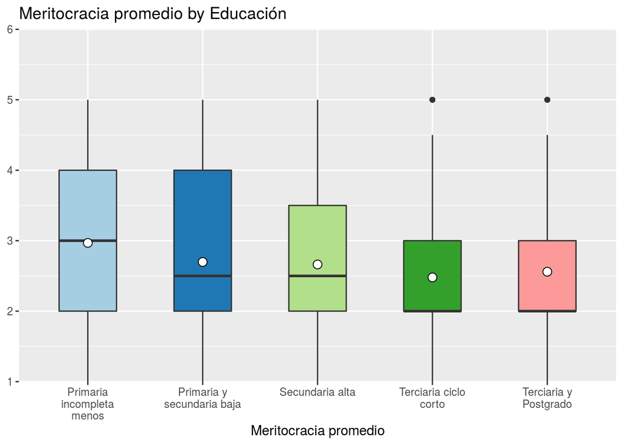

```r
plot_grpfrq(proc_elsoc$pmerit,proc_elsoc$edcine,
            type = "box")
```

#### 3.2.2.1 Correlaciones (variables continuas)

```r
M <- cor(proc_elsoc)
M
```

```
##              mesfuerzo    mtalento          ess      edcine        sexo
## mesfuerzo  1.000000000  0.69768811 -0.004312135 -0.12167659 -0.04480502
## mtalento   0.697688106  1.00000000  0.018447696 -0.10582754 -0.03759340
## ess       -0.004312135  0.01844770  1.000000000  0.28959248 -0.03745546
## edcine    -0.121676591 -0.10582754  0.289592479  1.00000000 -0.08682644
## sexo      -0.044805024 -0.03759340 -0.037455462 -0.08682644  1.00000000
## edad       0.096495547  0.07383771 -0.066031873 -0.37660283  0.06121699
## pmerit     0.920404032  0.92224547  0.007740598 -0.12341680 -0.04469515
##                  edad       pmerit
## mesfuerzo  0.09649555  0.920404032
## mtalento   0.07383771  0.922245465
## ess       -0.06603187  0.007740598
## edcine    -0.37660283 -0.123416804
## sexo       0.06121699 -0.044695146
## edad       1.00000000  0.092369792
## pmerit     0.09236979  1.000000000
```

```r
sjt.corr(proc_elsoc,
         triangle = "lower")
```

|  | Recompensa: esfuerzo | Recompensa: talento | Estatus Social Subjetivo | Educación | Sexo | Edad | Meritocracia promedio |
| --- | --- | --- | --- | --- | --- | --- | --- |
| Recompensa: esfuerzo |  |  |  |  |  |  |  |
| Recompensa: talento | 0.698*** |  |  |  |  |  |  |
| Estatus Social Subjetivo | -0.004 | 0.018 |  |  |  |  |  |
| Educación | -0.122*** | -0.106*** | 0.290*** |  |  |  |  |
| Sexo | -0.045* | -0.038* | -0.037* | -0.087*** |  |  |  |
| Edad | 0.096*** | 0.074*** | -0.066*** | -0.377*** | 0.061** |  |  |
| Meritocracia promedio | 0.920*** | 0.922*** | 0.008 | -0.123*** | -0.045* | 0.092*** |  |
| Computed correlation used pearson-method with listwise-deletion. |  |  |  |  |  |  |  |

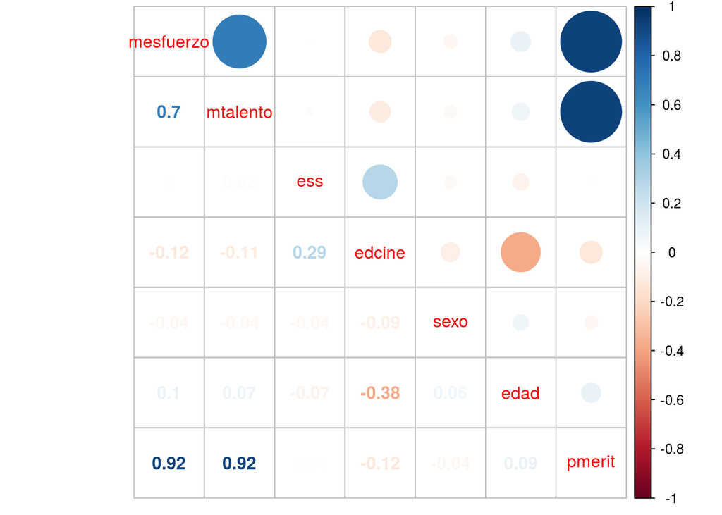

```r
corrplot.mixed(M)
```

```r
names(proc_elsoc)
```

```
## [1] "mesfuerzo" "mtalento"  "ess"       "edcine"    "sexo"      "edad"
## [7] "pmerit"
```

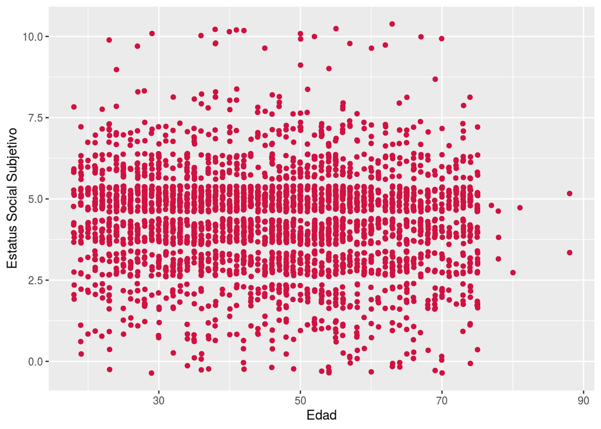

```r
plot_scatter(proc_elsoc, edad, ess)
```

# 4 Contraste de hipótesis

```r
reg1 <- lm(pmerit ~ ess + edcine + sexo + edad, data=proc_elsoc)
summary(reg1)
```

```
##
## Call:
## lm(formula = pmerit ~ ess + edcine + sexo + edad, data = proc_elsoc)
##
## Residuals:
##     Min      1Q  Median      3Q     Max
## -2.0659 -0.6752 -0.1902  0.7944  2.5866
##
## Coefficients:
##              Estimate Std. Error t value Pr(>|t|)
## (Intercept)  2.758703   0.101419  27.201  < 2e-16 ***
## ess          0.027442   0.011959   2.295  0.02183 *
## edcine      -0.097648   0.016757  -5.827 6.25e-09 ***
## sexo        -0.112629   0.036667  -3.072  0.00215 **
## edad         0.003383   0.001267   2.669  0.00765 **
## ---
## Signif. codes:  0 '***' 0.001 '**' 0.01 '*' 0.05 '.' 0.1 ' ' 1
##
## Residual standard error: 0.9602 on 2882 degrees of freedom
## Multiple R-squared:  0.02274,    Adjusted R-squared:  0.02138
## F-statistic: 16.77 on 4 and 2882 DF,  p-value: 1.358e-13
```

```r
stargazer(reg1, type = "html")
```

|  | *Dependent variable:* |
| --- | --- |
|  | pmerit |
| ess | 0.027** |
|  | (0.012) |
| edcine | -0.098*** |
|  | (0.017) |
| sexo | -0.113*** |
|  | (0.037) |
| edad | 0.003*** |
|  | (0.001) |
| Constant | 2.759*** |
|  | (0.101) |
| Observations | 2,887 |
| R<sup>2</sup> | 0.023 |
| Adjusted R<sup>2</sup> | 0.021 |
| Residual Std. Error | 0.960 (df = 2882) |
| F Statistic | 16.766*** (df = 4; 2882) |
| *Note:* | p<0.1; p<0.05; p<0.01 |

# 5 Información de la sesión de R